# Project-Group6-FlickRImageClassifier

Gokul Nedunsezhian, Jai Krishna Mounaguru, Rohit Madhu, Rohan Pathak, Balajhi Shanmugam Selvakumar

2023-04-25

## Problem Description

People are becoming more health conscious and interested in tracking their calorie intake.

An image classifier that can provide nutritional information based on the picture of the food taken could be a unique selling point for calorie-tracking apps.

We plan to scrape data using the FlickrAPI package to create an image classifier for food items and use it to output nutritional values of the respective food item.

## Link to Scrapped Data

Google Drive link with the training and test images

Link - https://drive.google.com/drive/folders/1wTq1eJN3_gbEVnaqtpZbWWJ5SwKh_xqT?usp=sharing

## Loading the Libraries

```r
# Load required libraries
library(tidyverse)
library(keras)
library(tensorflow)
library(reticulate)
library(jpeg)
library(httr)
library(knitr)
library(kableExtra)
library(dplyr)
library(ggplot2)
library(gridExtra)
```

## Downloading the Images

Use FlickR API to search for the 5500 most interesting pictures in each of the 4 catogories

```r
# Specify the food items to download
food_items <- c("burger", "banana", "apple", "pasta")

# Specify the directory to save the images
dir.create("training_data")
local_dir <- "training_data"
```

Loop through the food items and download the images

```r
# Loop through each food item
for (food_item in food_items) {
  # Create a subdirectory for this food item
  sub_dir <- paste(local_dir, "/", food_item, sep = "")
  dir.create(sub_dir)

  # Specify the number of images to download for this food item
  n_images <- 5500

  # Specify the number of images to download per request
  per_page <- 500

  # Specify the number of requests needed
  n_requests <- ceiling(n_images / per_page)

  # Loop through each request
  for (page in 1:n_requests) {
    # Calculate the starting index for this request
    start <- (page - 1) * per_page + 1

    # Make the API request for this page
    photos <- getPhotoSearch(api_key = "a78a61870fb226f1aa6e348cd78c075e",
                             tags = food_item,
                             extras = "url_o",
                             img_size = "m",
                             per_page = per_page,
                             page = page,
                             sort = "interestingness-desc")

    # Remove columns with NA values in url_o column
    photos <- subset(photos, !is.na(url_m))

    # Loop through each row in the dataframe for this request
    for (i in 1:nrow(photos)) {
      # Get the URL for the current photo
      url <- photos$url_m[i]

      # Extract the photo ID from the URL
      photo_id <- gsub(".*/", "", url)

      # Calculate the index of this photo
      index <- start + i - 1

      # Construct the filename by concatenating the index and the photo ID
      filename <- paste(sub_dir, "/", index, "-", photo_id, ".jpg", sep = "")

      # Try to download the photo, and skip if there is an error
      tryCatch(
        download.file(url, filename),
        error = function(e) {
          message(sprintf("Error downloading photo %s: %s", photo_id, e$message))
        }
      )

      # Stop the loop if we've reached the desired number of images
      if (index >= n_images) {
        break
      }
    }
  }
}
```

## Exploring the downloaded Images

Total training images - 19526

Total test images - 592

Total images - 20118

Though the target was 22000, due to download issues we got to download 91% of the scraped data.

592 of these images were manually tagged for the purpose of testing.

```r
# set the path to the directory you want to count the files in
path <- "train/"
path_test <- "test/"

# recursively list all files in the directory and its subdirectories
file_list <- list.files(path, recursive = TRUE, full.names = TRUE)
file_list_test <- list.files(path_test, recursive = TRUE, full.names = TRUE)

# count the number of image files and total files
image_count_train <- file_list %>%
  str_detect(".jpg|.jpeg|.png|.gif|.bmp") %>%
  sum()

image_count_test <- file_list_test %>%
  str_detect(".jpg|.jpeg|.png|.gif|.bmp") %>%
  sum()

total_images = image_count_train+image_count_test

# print the results
cat(paste0("Number of Training image files: ", image_count_train, "\n"))
```

```
## Number of Training image files: 19526
```

```r
cat(paste0("Number of Test image files: ", image_count_test, "\n"))
```

```
## Number of Test image files: 592
```

```r
cat(paste0("Number of Image files: ", total_images, "\n"))
```

```
## Number of Image files: 20118
```

## Image Processing & Augmentation

Getting the labels for data, Set the image dimensions & set up image data generator

```r
# Get the list of labels for each class
label_list <- dir("train/")
output_n <- length(label_list)
# Save the list of labels to a file
save(label_list, file="label_list.R")

# Set the dimensions for the input images
width <- 224
height<- 224
target_size <- c(width, height)
rgb <- 3 #color channels
```

Re scale the pixel values of the images to be between 0 and 1.

Specify a target_size of 224 x 224 pixels for the image for resizing.

```r
# Specify the path to the training data and create a data generator
path_train <- "train/"
train_data_gen <- image_data_generator(rescale = 1/255,
                                       validation_split = .6)
# Create a generator for the training images
train_images <- flow_images_from_directory(path_train,
                                           train_data_gen,
                                           subset = 'training',
                                           target_size = target_size,
                                           class_mode = "categorical",
                                           shuffle = TRUE,
                                           batch_size = 32,
                                           classes = label_list,
                                           seed = 2021)

# Create a generator for the validation images
validation_images <- flow_images_from_directory(path_train,
                                         train_data_gen,
                                         subset = "validation",
                                         target_size = target_size,
                                         class_mode = "categorical",
                                         shuffle = TRUE,
                                         batch_size = 32,
                                         classes = label_list,
                                         seed = 2021)
```

## Model building

Define a sequential model for image classification using transfer learning with the pre-trained Xception model as the base.

The base model is loaded with weights from the ImageNet dataset.

Its layers are frozen to prevent them from being updated during training.

```r
mod_base <- application_xception(weights = 'imagenet',
                                 include_top = FALSE, input_shape = c(width, height, 3))
freeze_weights(mod_base)

model_function <- function(learning_rate = 0.001,
                           dropoutrate=0.2, n_dense=1024){

  k_clear_session() # Clear any existing models in memory

  # Create a sequential model and add the pre-trained Xception model as the base
  model <- keras_model_sequential() %>%
    mod_base %>%
    # Add a global average pooling layer to reduce the number of parameters
    layer_global_average_pooling_2d() %>%
    # Add a dense layer with the specified number of units
    layer_dense(units = n_dense) %>%
    # Add a ReLU activation function
    layer_activation("relu") %>%
    # Add a dropout layer to prevent overfitting
    layer_dropout(dropoutrate) %>%
    # Add a final dense layer with the number of output classes and a softmax activation function
    layer_dense(units=output_n, activation="softmax")

  # Compile the model with categorical cross-entropy loss, Adam optimizer and accuracy metric
  model %>% compile(
    loss = "categorical_crossentropy",
    optimizer = optimizer_adam(lr = learning_rate),
    metrics = "accuracy"
  )

  # Return the compiled model
  return(model)

}
```

Deploy the Model

```r
# Create the neural network model using default parameter values
model <- model_function()
```

The Model is further trained on the training data

```r
model %>% fit(
  train_images,
  class_mode = "categorical",
  classes = label_list,
  epochs = 2, # modify the number of epochs if necessary
  validation_data = validation_images
)
```

Load the trained Model

```r
# Load the model
model <- load_model_hdf5("Project-Group6-FlickRImageClassifier.h5")
```

### Test the Accuracy of the model using the Test data

```r
path_test <- "test"
test_data_gen <- image_data_generator(rescale = 1/255)
test_images <- flow_images_from_directory(path_test,
                                          test_data_gen,
                                          target_size = target_size,
                                          class_mode = "categorical",
                                          classes = label_list,
                                          shuffle = F,
                                          seed = 2021)

model %>% evaluate_generator(test_images,
                             steps = test_images$n)
```

```
##      loss  accuracy
## 0.1495422 0.9459459
```

### Confusion Matrix

```r
# Make predictions on test images
pred <- predict(model, test_images)

# Get predicted labels
pred_labels <- label_list[apply(pred, 1, which.max)]

# Get true labels
true_labels <- test_images$classes

# Create confusion matrix
conf_mat <- table(pred_labels, true_labels)

# Print confusion matrix
#print(conf_mat)
# Convert table to data frame
conf_mat_df <- as.data.frame.matrix(conf_mat)

# Print confusion matrix using kable
kable(conf_mat_df, format = "html", caption = "Confusion Matrix")
```

Confusion Matrix

|  | 0 | 1 | 2 | 3 |
| --- | --- | --- | --- | --- |
| apple | 108 | 1 | 0 | 0 |
| banana | 29 | 193 | 1 | 0 |
| burger | 0 | 0 | 101 | 0 |
| pasta | 0 | 0 | 1 | 158 |

### Class level Accuracy, Precision & Recall

```r
# Compute class-level accuracy
class_acc <- diag(conf_mat) / colSums(conf_mat, na.rm = TRUE) * 100
names(class_acc) <- label_list
print(paste(round(class_acc, 2), "%", sep = ""))
```

```
## [1] "78.83%" "99.48%" "98.06%" "100%"
```

```r
# Compute precision
precision <- diag(conf_mat) / colSums(conf_mat) * 100
names(precision) <- label_list
print(paste(round(precision, 2), "%", sep = ""))
```

```
## [1] "78.83%" "99.48%" "98.06%" "100%"
```

```r
# Compute recall
recall <- diag(conf_mat) / rowSums(conf_mat) * 100
names(recall) <- label_list
print(paste(round(recall, 2), "%", sep = ""))
```

```
## [1] "99.08%" "86.55%" "100%"   "99.37%"
```

The overall accuracy is still at 94.6%.

### Testing a random image downloaded from a google search

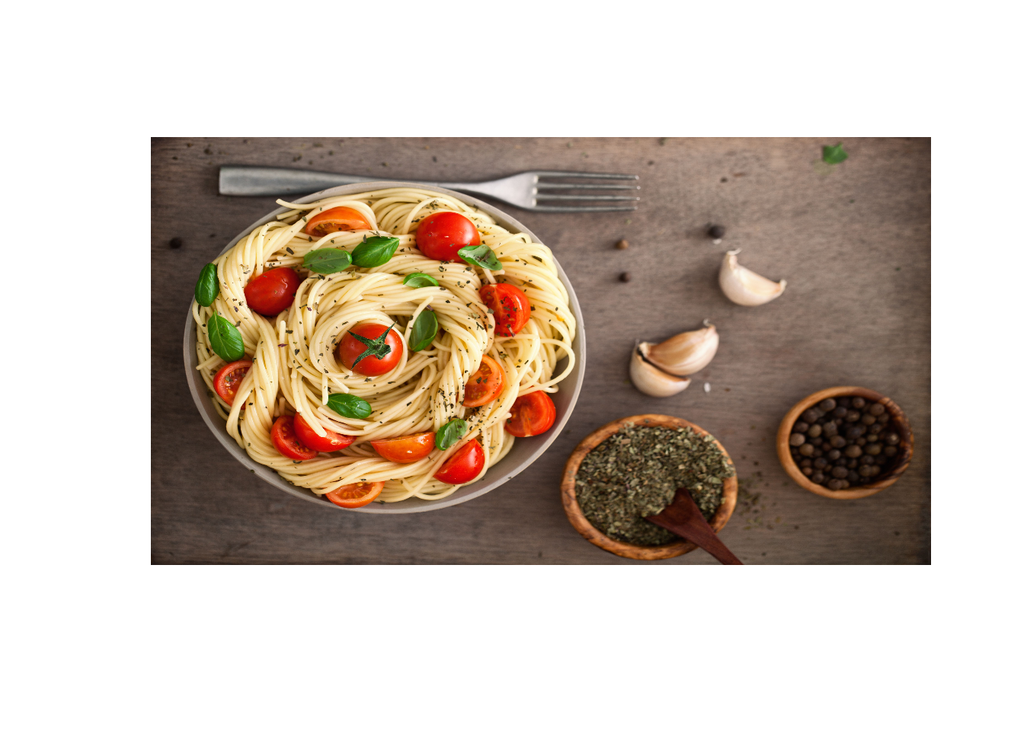

```r
# Load test image
test_image <- image_load("pasta11.jpg",
                         target_size = target_size)


# Display the image
img <- readJPEG("pasta11.jpg")
plot(0, 0, type = "n", xlim = c(0, 1), ylim = c(0, 1), axes = FALSE, ann = FALSE)
rasterImage(img, 0, 0, 1, 1)
```

```r
# Preprocess image
x <- image_to_array(test_image)
x <- array_reshape(x, c(1, dim(x)))
x <- x/255


# Make predictions and create a data frame
pred <- model %>% predict(x)

Probability = t(pred)


pred_df <- data.frame("Food" = label_list, Probability)
pred_df <- pred_df[order(pred_df$Probability, decreasing = TRUE),][1:4,]
pred_df$Probability <- paste0(format(round(100*as.numeric(pred_df$Probability), 2), nsmall = 2), " %")
pred_df <- pred_df[complete.cases(pred_df), ]

# Display results in a table
library(knitr)
kable(pred_df, align = "c", row.names = FALSE, col.names = c("", "Probability"))
```

|  | Probability |
| --- | --- |
| pasta | 93.12 % |
| banana | 5.53 % |
| burger | 1.24 % |
| apple | 0.11 % |

### Determining the nutritional info

```r
classified_food = label_list[which.max(t(pred))]

# specify API endpoint URL and parameters
url <- "https://api.nal.usda.gov/fdc/v1/foods/search"
params <- list(api_key = "n1ivodEIAZmzjfRczeaehpZgmb7mOvISJYu644u2", query = classified_food)

# make GET request to API endpoint with parameters and API key
response <- GET(url, query = params)

# extract response content as text
response_text <- content(response, "text")

# parse response text as JSON
response_data <- jsonlite::fromJSON(response_text)


# extract relevant data from response object
food_list <- list(response_data$foods)
food_name <- food_list[[1]]$description
calories_data <- food_list[[1]]$foodNutrients

nutr_df<-calories_data[[1]]

nutr_df <- nutr_df %>%
  select(-nutrientId, -nutrientNumber, -derivationCode, -
           derivationDescription, -derivationId, -foodNutrientSourceId,
         -foodNutrientSourceCode, -foodNutrientSourceDescription,
         -rank, -indentLevel,-foodNutrientId)



# replace missing values with 0
nutr_df[is.na(nutr_df)] <- 0

# replace missing values with 0
nutr_df[is.na(nutr_df)] <- 0

# sort the data frame based on percentDailyValue
nutr_df <- nutr_df[order(-nutr_df$percentDailyValue),]

# print extracted data to console
cat(paste("Food Name: ", food_name[1], "\n"))
```

```
## Food Name:  PASTA
```

```r
cat("Nutrients Data: \n")
```

```
## Nutrients Data:
```

```r
kable(nutr_df, col.names = c("Nutrient Name", "Unit Name", "Value", "Percent Daily Value"))
```

|  | Nutrient Name | Unit Name | Value | Percent Daily Value |
| --- | --- | --- | --- | --- |
| 6 | Thiamin | MG | 1.000 | 30 |
| 8 | Niacin | MG | 5.360 | 15 |
| 13 | Carbohydrate, by difference | G | 78.600 | 15 |
| 2 | Iron, Fe | MG | 3.210 | 10 |
| 7 | Riboflavin | MG | 0.304 | 10 |
| 16 | Fiber, total dietary | G | 3.600 | 8 |
| 12 | Total lipid (fat) | G | 1.790 | 2 |
| 1 | Calcium, Ca | MG | 0.000 | 0 |
| 3 | Sodium, Na | MG | 0.000 | 0 |
| 4 | Vitamin A, IU | IU | 0.000 | 0 |
| 5 | Vitamin C, total ascorbic acid | MG | 0.000 | 0 |
| 9 | Cholesterol | MG | 0.000 | 0 |
| 10 | Fatty acids, total saturated | G | 0.000 | 0 |
| 11 | Protein | G | 12.500 | 0 |
| 14 | Energy | KCAL | 375.000 | 0 |
| 15 | Sugars, total including NLEA | G | 3.570 | 0 |
| 17 | Fatty acids, total trans | G | 0.000 | 0 |

```r
# Print the Calories

energy_value <- nutr_df[nutr_df$nutrientName == 'Energy', 'value'][1]
cat("It contains", energy_value, "calories.")
```

```
## It contains 375 calories.
```

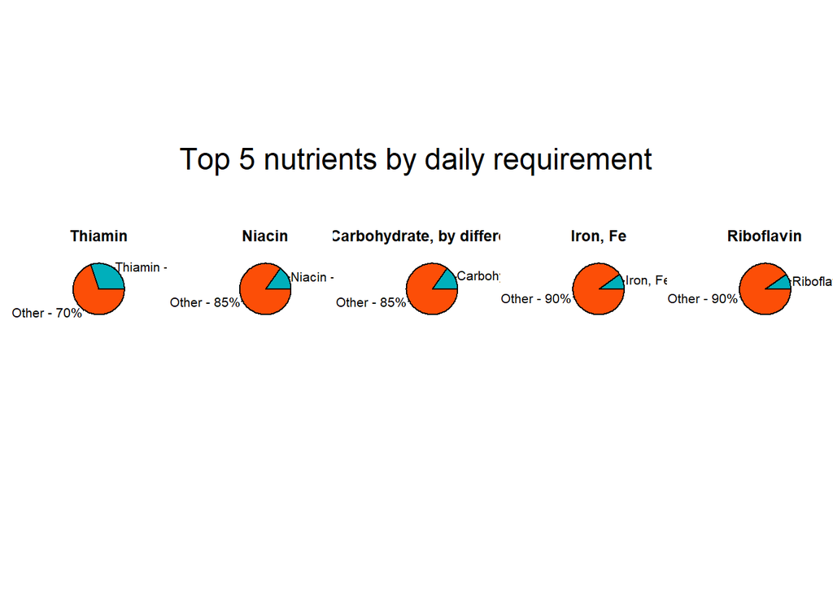

```r
# Set up plot window grid
par(mfrow = c(1, 5))

# Display the top 5 nutrients based on Daily Requirement according to the FDA

for (i in 1:5) {

  # Create a vector for the data to be used in the pie chart
  pie_data <- c(nutr_df[i,"percentDailyValue"], 100-nutr_df[i,"percentDailyValue"])

  # Create a vector for the labels to be used in the pie chart
  pie_labels <- c(paste0(nutr_df[i,"nutrientName"], " - ", nutr_df[i,"percentDailyValue"], "%"),
                  paste0("Other - ", 100-nutr_df[i,"percentDailyValue"], "%"))

  # Create the pie chart
  pie(pie_data, labels = pie_labels, col =  c("#00AFBB", "#FC4E07"), cex.main = 0.8)

  # Add the title within the plot area
  title(nutr_df[i,"nutrientName"], line = -11.25, cex.main = 1.2)
}

# Add the main title above the plot area
main_title <- "Top 5 nutrients by daily requirement"
mtext(main_title, outer = TRUE, line = -11, cex = 1.5)
```